# Impact Survey Data Quality and Monitoring Report

Synthetic dataset — no real respondents or operations

Published

July 10, 2026

```r
source(file.path("R", "bootstrap.R"))
bootstrap_project_library()
Sys.setenv(IMPACT_PROJECT_ROOT = normalizePath(getwd(), winslash = "/"))
library(dplyr)
library(readr)
library(knitr)

processed <- file.path("data", "processed")
headline <- read_csv(
  file.path(processed, "headline_metrics_synthetic.csv"),
  show_col_types = FALSE
)
issue_summary <- read_csv(
  file.path(processed, "qc_issue_summary_synthetic.csv"),
  show_col_types = FALSE
)
region_round <- read_csv(
  file.path(processed, "region_round_summary_synthetic.csv"),
  show_col_types = FALSE
)
gender_participation <- read_csv(
  file.path(processed, "gender_participation_synthetic.csv"),
  show_col_types = FALSE
)
qualitative_summary <- read_csv(
  file.path(processed, "qualitative_theme_summary_synthetic.csv"),
  show_col_types = FALSE
)
qualitative_comments <- read_csv(
  file.path(processed, "qualitative_comments_coded_synthetic.csv"),
  show_col_types = FALSE
)

metric_value <- function(metric_name) {
  headline$value[headline$metric == metric_name][[1]]
}
```

## Purpose and data boundary

This report presents a reproducible monitoring and data-quality workflow. Every response, identifier, site, and comment is synthetic. The survey does not collect names, contact details, addresses, GPS coordinates, or exact birth dates. Results must not be interpreted as evidence about a real population or programme.

## Data-quality findings

Automated rules detected 60 record-level flags affecting 58 submissions. One record can trigger more than one rule, so these counts are not interchangeable.

```r
issue_summary |>
  select(issue_label, flag_count, affected_response_ids) |>
  rename(
    `QC rule` = issue_label,
    `Record-level flags` = flag_count,
    `Affected response IDs` = affected_response_ids
  ) |>
  kable(digits = 1)
```

Table 1: Automated QC results

| QC rule | Record-level flags | Affected response IDs |
| --- | --- | --- |
| Duplicate response identifier | 20 | 10 |
| Missing required value | 8 | 8 |
| Skip-logic violation | 8 | 8 |
| Date inconsistency | 6 | 6 |
| Invalid code | 6 | 6 |
| Value outside allowed range | 6 | 6 |
| Region/site inconsistency | 6 | 6 |

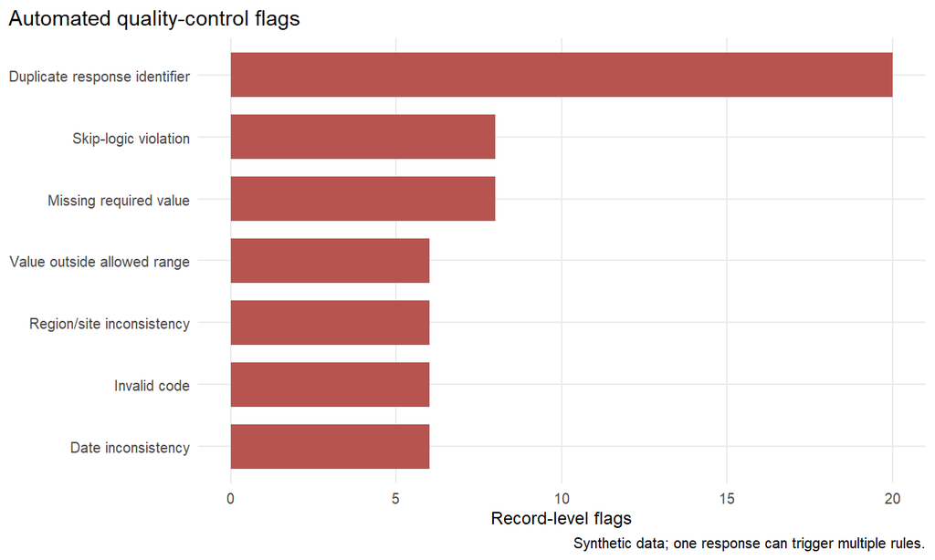

Figure 1: Counts of automated record-level flags

Flags remain visible in the validated dataset. The analysis copy keeps one record per response identifier, converts invalid codes and out-of-range numeric values to missing, and uses rule-specific denominators. Raw values are never overwritten.

## Monitoring summary

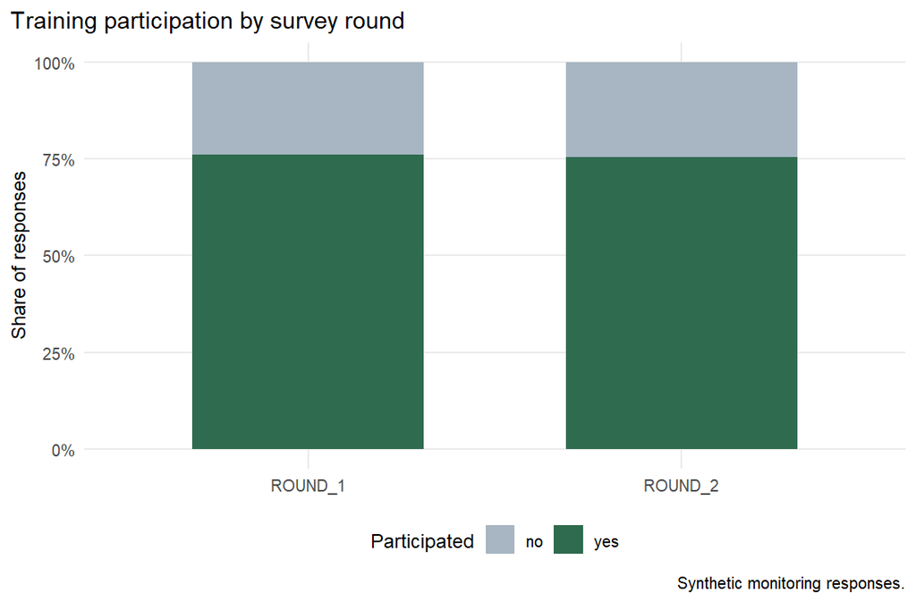

Figure 2: Training participation by monitoring round

```r
region_round |>
  mutate(
    participation_rate = scales::percent(participation_rate, accuracy = 0.1),
    mean_satisfaction = round(mean_satisfaction, 2),
    mean_service_access = round(mean_service_access, 2)
  ) |>
  rename(
    Region = region_code,
    Round = survey_round,
    Responses = responses,
    Participants = training_participants,
    `Participation rate` = participation_rate,
    `Mean satisfaction` = mean_satisfaction,
    `Mean service access` = mean_service_access,
    `Follow-up requests` = follow_up_requests
  ) |>
  kable()
```

Table 2: Monitoring indicators by fictional region and round

| Region | Round | Responses | Participants | Participation rate | Mean satisfaction | Mean service access | Follow-up requests |
| --- | --- | --- | --- | --- | --- | --- | --- |
| EAST | ROUND_1 | 49 | 38 | 77.6% | 4.00 | 3.61 | 12 |
| EAST | ROUND_2 | 69 | 58 | 84.1% | 3.95 | 3.41 | 19 |
| NORTH | ROUND_1 | 40 | 30 | 75.0% | 3.53 | 3.38 | 7 |
| NORTH | ROUND_2 | 59 | 42 | 71.2% | 4.00 | 3.63 | 19 |
| SOUTH | ROUND_1 | 40 | 27 | 67.5% | 4.00 | 3.52 | 13 |
| SOUTH | ROUND_2 | 49 | 32 | 65.3% | 3.69 | 3.51 | 11 |
| WEST | ROUND_1 | 42 | 35 | 83.3% | 3.51 | 3.60 | 10 |
| WEST | ROUND_2 | 52 | 40 | 76.9% | 3.95 | 3.75 | 13 |

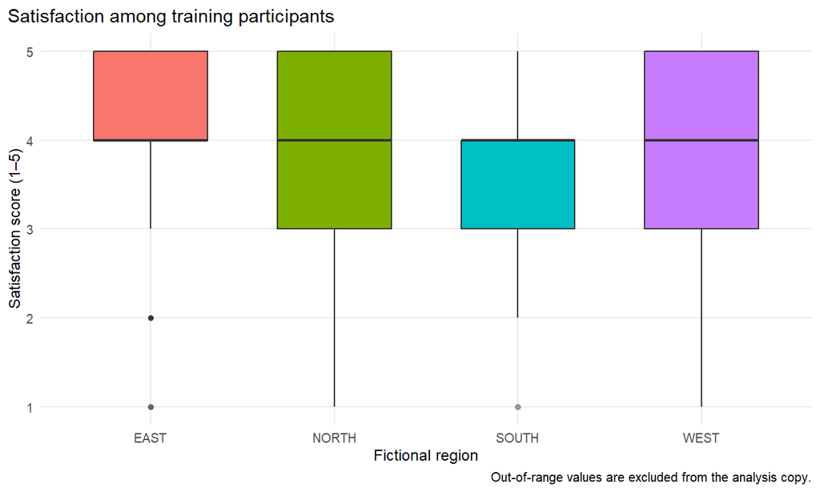

Figure 3: Satisfaction distribution by fictional region

### Cross-tabulation

```r
gender_participation |>
  rename(
    Gender = gender,
    Participated = participated_training,
    Responses = responses,
    `Percent within gender` = percent_within_gender
  ) |>
  kable()
```

Table 3: Training participation by gender category

| Gender | Participated | Responses | Percent within gender |
| --- | --- | --- | --- |
| man | no | 46 | 25.1 |
| man | yes | 137 | 74.9 |
| non_binary | no | 2 | 20.0 |
| non_binary | yes | 8 | 80.0 |
| prefer_not | no | 1 | 16.7 |
| prefer_not | yes | 5 | 83.3 |
| woman | no | 49 | 24.4 |
| woman | yes | 152 | 75.6 |

## Synthetic qualitative comments

The optional comments come from a documented synthetic phrase library. A transparent keyword rule assigns one theme to each comment. This supports an inspectable data-management and reporting workflow, but it is not a substitute for iterative human coding of real qualitative data.

```r
qualitative_summary |>
  rename(
    Theme = theme,
    Comments = comment_count,
    `Percent of comments` = percent_of_comments
  ) |>
  kable()
```

Table 4: Themes in synthetic open comments

| Theme | Comments | Percent of comments |
| --- | --- | --- |
| Positive learning experience | 31 | 43.1 |
| Request for more content | 15 | 20.8 |
| Access and materials | 14 | 19.4 |
| Timing and scheduling | 12 | 16.7 |

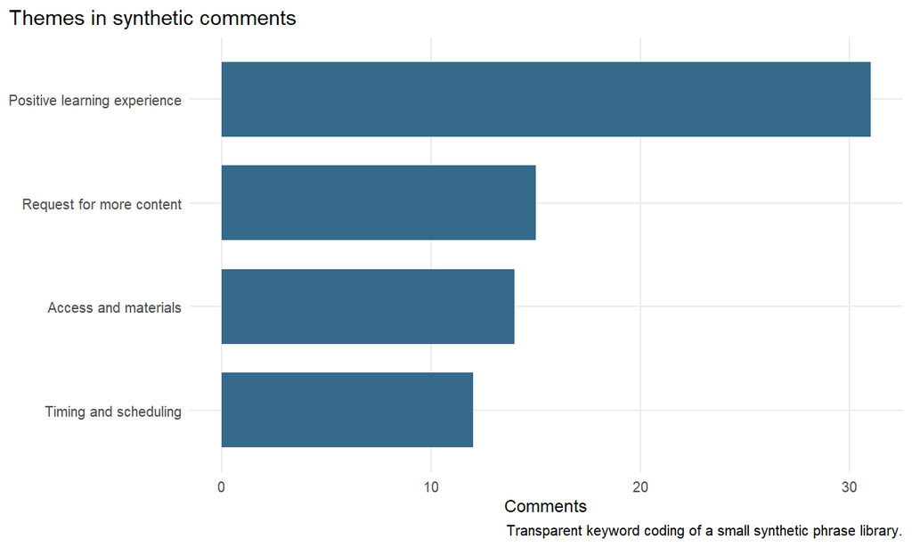

Figure 4: Distribution of coded synthetic comments

Representative synthetic examples are shown only to make the coding method auditable:

```r
qualitative_comments |>
  group_by(theme) |>
  slice_head(n = 1) |>
  ungroup() |>
  select(theme, open_comment) |>
  rename(Theme = theme, `Synthetic example` = open_comment) |>
  kable()
```

Table 5: One synthetic example per assigned theme

| Theme | Synthetic example |
| --- | --- |
| Access and materials | A location closer to the community would improve attendance. |
| Positive learning experience | The facilitator explained the topic clearly and respectfully. |
| Request for more content | More time for questions and practice would improve the training. |
| Timing and scheduling | Shorter sessions on more days would be easier to attend. |

## Limitations

- The data-generating assumptions determine every apparent pattern.
- Deliberate errors are more structured than errors in most live systems.
- Duplicate handling keeps the first submission identifier under a documented deterministic rule; a live project would confirm the resolution with the data owner.
- Invalid and out-of-range values are set to missing only in the analysis copy.
- Theme coding is based on a small synthetic phrase library and is not suitable for inference.
- Excel and KoboToolbox have separate manual verification requirements and are not validated by this report.

## Reproducibility

From the repository root, restore dependencies, run the pipeline and tests, then render this report:

```
Rscript -e "renv::restore(prompt = FALSE)"
Rscript scripts/run_pipeline.R
Rscript tests/testthat.R
quarto render reports/impact_survey_report.qmd
```